# Introduction to R

石长顺

2015年10月21日

# 一.下载安装R

# Windows

1. 打开网址：http://www.r-project.org
2. 点击“[CRAN](https://cran.r-project.org/mirrors.html)”, 选择最近的镜像
3. 点击“Download R for Windows”。
4. 点击“base”, 下载最新版本的R[Download R 3.2.2 for Windows](http://mirrors.xmu.edu.cn/CRAN/bin/windows/base/R-3.2.2-win.exe).
5. 下载完成后双击安装包进行安装。

**关于路径** 1.安装时最好在默认路径（Windows C:） 2. 路径内最好不要含有中文

[安装教程](http://wise-r.github.io/2015/10/06/install-R-Windows.html) http://wise-r.github.io/2015/10/06/install-R-Windows.html

# OSX

1. 打开网址：http://www.r-project.org
2. 点击“[CRAN](https://cran.r-project.org/mirrors.html)”, 选择最近的镜像
3. 点击“Download R for （Mac）OSX”。
4. 点击“R-3.2.2.pkg”, 下载最新版本的R.
5. 下载完成后双击安装包进行安装。

[安装教程](http://wise-r.github.io/2015/10/06/install-R-Mac.html) http://wise-r.github.io/2015/10/06/install-R-Mac.html

# R的界面

[figure not shown]

# RStudio

> RStudio 是最流行的R语言的编辑器, 包含`高亮显示`， `自动补全`，`图形显示和管理`，`对象管理`， `Rmarkdown文档编辑和输出`等功能。

[安装教程](http://wise-r.github.io/2015/10/06/install-R-Windows.html#rstudio)http://wise-r.github.io/2015/10/06/install-R-Windows.html#rstudio

# 二、Hello World

# Hello World

```r
"Hello World"
```

```
## [1] "Hello World"
```

# 变量和赋值

赋值符号有`<-`和`=`, 大部分时候两种效果是一样的，推荐使用`<-`进行赋值

```r
x <- 1
x
```

```
## [1] 1
```

```r
y <- "Hello World"
y
```

```
## [1] "Hello World"
```

```r
x <- y
x
```

```
## [1] "Hello World"
```

# 作为科学计算器的R

```r
1+1
```

```
## [1] 2
```

```r
2*2
```

```
## [1] 4
```

```r
10/3
```

```
## [1] 3.333333
```

```r
3^10
```

```
## [1] 59049
```

# 作为科学计算器的R

```r
log10(100)
```

```
## [1] 2
```

```r
pi
```

```
## [1] 3.141593
```

```r
sin(pi/2)
```

```
## [1] 1
```

# 简单的函数

```r
x <- c(1, 3, 5, 7, 10)
y <- seq(10, 100, length=5)
sum(x)
```

```
## [1] 26
```

```r
max(y)
```

```
## [1] 100
```

# 简单的函数

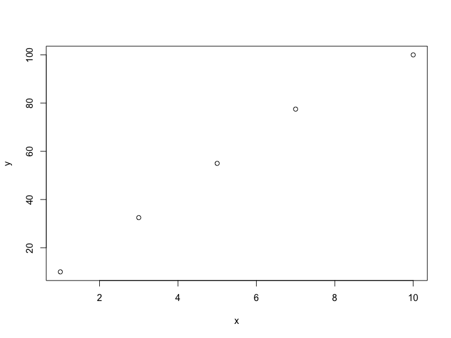

```r
plot(x, y)
```

# 工作目录（Work Directory）

> 操作R时有一个默认的工作目录，该目录下的文件可以直接访问， 否则要输入完整的路径。

```r
getwd()
setwd("/Users/shihchosen/Documents/R/R-workplace/WISER/R_Basic2015")  #MAC OS
setwd("C:/Users/shihchosen")  # Windows
setwd("C:\\Users\\shihchosen")
```

# 显示和删除已有变量

`ls()`和`rm()`

```r
ls()
```

```
## [1] "x" "y"
```

```r
rm(x)
rm(list=ls())
```

# 工作空间(Workspace)

> 工作空间是包含用户建立的对象的工作环境， 保存环境后下次载入时可以重复利用。

```r
save.image()
```

*一般不建议保存工作空间， 为什么呢？*

# 脚本(script)

R脚本是存放R代码的文本文件，后缀是`*.R` 我们推荐把代码写在脚本里，方便管理和重复使用 使用脚本里的代码

```r
#setwd("/Users/shihchosen/Documents/R/R-workplace/WISER/
 #     R_Basic2015/Introduction_to_R")
source("intro2r.R")
```

# 三、package(包)

# 什么是package

### package

R中的包是R函数、数据和代码的collections.

### 核心包

`"stats","graphics" "grDevices", "utils","datasets","methods"， "base"`

# 常用的包

截至2015年10月21日，CRAN上存有7358个包。

1. **Rcpp** Seamless R and C++ Integration.
2. **ggplot2** An Implementation of the Grammar of Graphics
3. **stringr** Simple, Consistent Wrappers for Common String Operations.
4. **plyr** Tools for Splitting, Applying and Combining Data.
5. **reshape2** Flexibly Reshape Data.
6. **RCurl** General network (HTTP/FTP/…) client interface for R.
7. **knitr** A General-Purpose Package for Dynamic Report Generation in R.

# 怎么安装包

### 方法一：命令行

```r
install.packges('packagename')
```

### 方法二： 菜单命令

### 方法三： 手动安装

CRAN上手动下载`*.zip`文件解压到安装目录下的`library`文件夹。

```r
.libPaths()
```

**注意**：严重推荐第一种！

# 怎么使用包

```r
library('packagename')
```

# 四、帮助系统

# R内部帮助系统

1. `help.start()` R帮助文档首页
2. `help("functionnamme")` 查看某个叫`functionname`这个函数的详细介绍(函数所在的包必须要加载)。
3. `help(package="packagename")` 查看叫`packagename`的包的详细介绍
4. `?functionnamme` 同`help("functionnamme")`
5. `??functionname` 模糊搜索。
6. `example(functionname)` 示例
7. `vignette('vignettename')`

# R内部帮助系统

```r
help.start()
help("plot")
help(package="ggplot2")
?plot
?"ggplot"
??"ggplot"
example(qplot) # require(ggplot2)
vignette("introduction") #require(dplyr)
```

# 外部资源

### 我需要什么包？

1. CRAN [Task View](https://cran.r-project.org/web/views/) https://cran.r-project.org/web/views
2. [Rdocumentation.org](http://www.rdocumentation.org/) http://www.rdocumentation.org/

### 我遇到了bug

1. 搜索[StackOverflow](http://stackoverflow.com/questions/tagged/r)http://stackoverflow.com/questions/tagged/r
2. Google. 尽量用英文搜索。 Google 的替代方案AOL http://search.aol.com/aol/webhome (结果是由google提供)

搜索时的格式可以采取，`'issue' in r`

# 主动求解 Con’d

1. 去[StackOverflow](http://stackoverflow.com/questions/tagged/r)http://stackoverflow.com/questions/tagged/r问问题
2. 去统计之都等论坛 http://cos.name/cn/去问
3. QQ群
4. 向`package`包作者发邮件。

# 五、学习资源

# 在线教程

1. Try R: http://tryr.codeschool.com/
2. Quick R: http://www.statmethods.net/
3. Learn R: http://renkun.me/learnR/
4. 153 分钟学会 R https://cran.r-project.org/doc/contrib/Liu-FAQ.pdf
5. Coursera - R Programming: https://www.coursera.org/course/rprog

# 学习网站

1. CRAN: https://cran.r-project.org
2. R-bloggers: http://www.r-bloggers.com/
3. Stackoverflow: http://stackoverflow.com/questions/tagged/r
4. 统计之都: http://cos.name/
5. UCLA stat http://www.ats.ucla.edu/stat/r/

# 书

1. R 实战(R in Action): 最流行 前面的BASIC PART
2. R 语言编程艺术(The.Art.of.R.Programming)，推荐
3. R 语言经典实例(r cookbook),涵盖200多个R语言实用方法, 查阅比较方便。

# Cheat sheet

> “cheat sheet” “有些考试时可以带一张小抄 通常老师会规定它的大小 或是单面双面等等”

# R Reference Card https://cran.r-project.org/doc/contrib/Baggott-refcard-v2.pdf

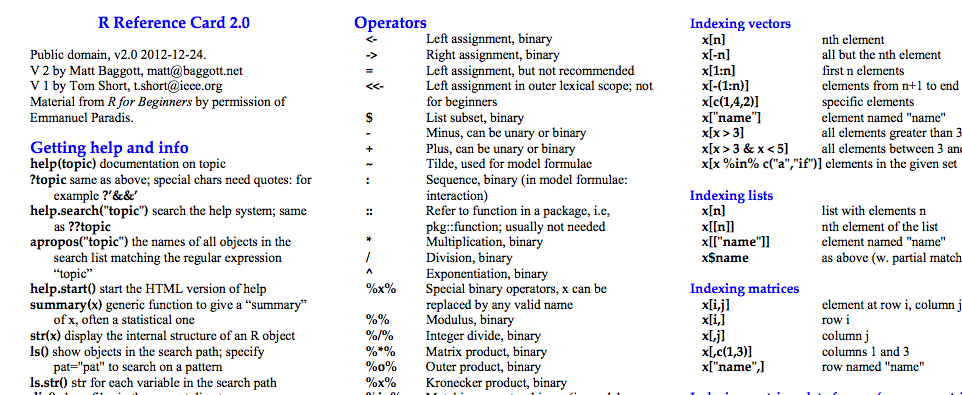

# 练习

# 练习1

**Try R** http://tryr.codeschool.com/ level 1